# 2IS50 – Software Development for Engineers – 2022-2023

[figure not shown]

## Lecture 6.A (Python)

Lecturer: Tom Verhoeff

Also see the book **Think Python** (2e), by Allen Downey

### Review of Lecture 5.A

- Robustness
  - Exceptions, `try: ... except: ... finally: ...`, `raise`
- Iterators and iterables
- Object-oriented programming (OOP)
  - Composition of classes
  - Define your own collection

### Preview of Lecture 6.A

- Object-Oriented Programming
  - Inheritance, subclass, superclass
  - Polymorphism
- Argument gathering
- Recursion

```python
%load_ext nb_mypy
# enable mypy type checking
if 'nb_mypy' in get_ipython().magics_manager.magics.get('line'):
    %nb_mypy On
    %nb_mypy
else:
    print("nb-mypy.py not installed")
```

```
Version 1.0.3
State: On DebugOff
```

```python
# Preliminaries

import collections as co
from typing import Tuple, List, Set, Dict, DefaultDict, Counter
from typing import Any, Optional
from typing import Sequence, Mapping, MutableMapping, Iterable, Iterator, Callable
from typing import NewType, TypeVar
import math
import random
from pprint import pprint
import itertools as it
import doctest
```

## More Rock-Paper-Scissors

- Lecture 4-B showed a monolithic RPS program:
  - Random opponent with given distribution
  - Try all my options against all permutations of opponent
  - Collect outcomes and determine best and guessed option\ (Guess: beat the opponent's most frequent option)

```python
r, p, s = 0.1, 0.4, 0.5  # probabilities of random-playing opponent
swap_left = True  # which pair to swap next: left vs. right

for k in range(6):
    print(f"Opponent's probability distribution: {r:1.2f}, {p:1.2f}, {s:1.2f}")
    wins = 3 * [0]  # initialize win counts for all options
    # Try each of my choices

    for choice_me in range(3):  # rock, paper, scissors
        print(f"My choice: {choice_me}")
        # Play one thousand games, and gather statistics

        for i in range(1000):
            choice_opponent = choice_me  # to start the loop

            while choice_me == choice_opponent:
                choice_opponent = random.choices([0, 1, 2], weights=[r, p, s], k=1)[0]

            if (choice_me - choice_opponent) % 3 == 1:
                wins[choice_me] += 1

        print(f"  win - lose: {wins[choice_me]} - {1000 - wins[choice_me]}")

    # determine my best choice (argmax)
    best_choice = max(range(3), key=lambda x: wins[x])
    print(f"My best choice: {best_choice}")

    # determine what beats highest probability (argmax, again)
    guessed_choice = (max(range(3), key=lambda x: [r, p, s][x]) + 1) % 3
    print(f"Guessed choice: {guessed_choice}", end='\n\n')

    if swap_left:
        r, p = p, r
    else:
        p, s = s, p
    swap_left = not swap_left
```

```
Opponent's probability distribution: 0.10, 0.40, 0.50
My choice: 0
  win - lose: 552 - 448
My choice: 1
  win - lose: 158 - 842
My choice: 2
  win - lose: 799 - 201
My best choice: 2
Guessed choice: 0

Opponent's probability distribution: 0.40, 0.10, 0.50
My choice: 0
  win - lose: 832 - 168
My choice: 1
  win - lose: 447 - 553
My choice: 2
  win - lose: 186 - 814
My best choice: 0
Guessed choice: 0

Opponent's probability distribution: 0.40, 0.50, 0.10
My choice: 0
  win - lose: 169 - 831
My choice: 1
  win - lose: 811 - 189
My choice: 2
  win - lose: 532 - 468
My best choice: 1
Guessed choice: 2

Opponent's probability distribution: 0.50, 0.40, 0.10
My choice: 0
  win - lose: 202 - 798
My choice: 1
  win - lose: 843 - 157
My choice: 2
  win - lose: 412 - 588
My best choice: 1
Guessed choice: 1

Opponent's probability distribution: 0.50, 0.10, 0.40
My choice: 0
  win - lose: 817 - 183
My choice: 1
  win - lose: 529 - 471
My choice: 2
  win - lose: 157 - 843
My best choice: 0
Guessed choice: 1

Opponent's probability distribution: 0.10, 0.50, 0.40
My choice: 0
  win - lose: 447 - 553
My choice: 1
  win - lose: 209 - 791
My choice: 2
  win - lose: 819 - 181
My best choice: 2
Guessed choice: 2
```

- Applying *functional* decomposition can yield  
  (differs from decomposition in 4-B):

```python
# Compacted code (WARNING: violates Python Coding Standard; how so?)

Option = NewType('Option', int)
ROCK, PAPER, SCISSORS = Option(0), Option(1), Option(2)
OPTIONS: List[Option] = [ROCK, PAPER, SCISSORS]
option_str = {ROCK: "ROCK", PAPER: "PAPER", SCISSORS: "SCISSORS"}

Outcome = NewType('Outcome', int)
TIE = Outcome(0)
outcome_str = {TIE: "TIE", 1: "1 wins", 2: "2 wins"}

def judge_encounter(choice_1: Option, choice_2: Option) -> Outcome:
    return Outcome((choice_1 - choice_2) % len(OPTIONS))

Distribution = Sequence[float]

def choose_random(distr: Distribution) -> Option:
    return Option(random.choices(OPTIONS, weights=distr, k=1)[0])

ChoiceFunction = Callable[[], Option]

def play_game(choice_1: ChoiceFunction, choice_2: ChoiceFunction) -> Outcome:
    result = TIE
    while result == TIE:
        result = judge_encounter(choice_1(), choice_2())
    return result

def play_games(n: int, choice_1: ChoiceFunction, choice_2: ChoiceFunction) -> int:
    return sum(play_game(choice_1, choice_2) % 2 for _ in range(n))

Statistics = Mapping[Option, int]

def play_all_my_games(n: int, distr_2: Distribution) -> Statistics:
    return {choice_me: play_games(n, lambda: choice_me, lambda: choose_random(distr_2))
            for choice_me in OPTIONS}

def best_choice(wins: Statistics) -> Option:
    return max(OPTIONS, key=lambda x: wins[x])

def guessed_choice(distr: Distribution) -> Option:
    return Option((max(OPTIONS, key=lambda x: distr[x]) + 1) % len(OPTIONS))

def experiment(distr_2: Distribution, n: int) -> None:
    for distr in it.permutations(distr_2):
        print("Opponent's probability distribution: {:1.2f}, {:1.2f}, {:1.2f}".format(*distr))
        wins = play_all_my_games(n, distr)
        for choice_me, win in wins.items():
            print(f"I choose {option_str[choice_me]:10}: win - lose: {win} - {n - win}")
        print(f"My best and guessed choices: {option_str[best_choice(wins)]} - {option_str[guessed_choice(distr)]}\n")

experiment([0.1, 0.4, 0.5], 1000)
```

```
Opponent's probability distribution: 0.10, 0.40, 0.50
I choose ROCK      : win - lose: 546 - 454
I choose PAPER     : win - lose: 189 - 811
I choose SCISSORS  : win - lose: 787 - 213
My best and guessed choices: SCISSORS - ROCK

Opponent's probability distribution: 0.10, 0.50, 0.40
I choose ROCK      : win - lose: 436 - 564
I choose PAPER     : win - lose: 216 - 784
I choose SCISSORS  : win - lose: 847 - 153
My best and guessed choices: SCISSORS - SCISSORS

Opponent's probability distribution: 0.40, 0.10, 0.50
I choose ROCK      : win - lose: 812 - 188
I choose PAPER     : win - lose: 441 - 559
I choose SCISSORS  : win - lose: 190 - 810
My best and guessed choices: ROCK - ROCK

Opponent's probability distribution: 0.40, 0.50, 0.10
I choose ROCK      : win - lose: 184 - 816
I choose PAPER     : win - lose: 803 - 197
I choose SCISSORS  : win - lose: 560 - 440
My best and guessed choices: PAPER - SCISSORS

Opponent's probability distribution: 0.50, 0.10, 0.40
I choose ROCK      : win - lose: 802 - 198
I choose PAPER     : win - lose: 553 - 447
I choose SCISSORS  : win - lose: 173 - 827
My best and guessed choices: ROCK - PAPER

Opponent's probability distribution: 0.50, 0.40, 0.10
I choose ROCK      : win - lose: 201 - 799
I choose PAPER     : win - lose: 846 - 154
I choose SCISSORS  : win - lose: 454 - 546
My best and guessed choices: PAPER - PAPER
```

- Do you understand `play_games`, using *generator expression*?
- Function `play_all_my_games` was decomposed further (SRP)
  - play `n` games for each option and return `Statistics`  
    using a *dictionary comprehension*
  - functions `best_choice` and `guess_choice`
- All printing is now done in `experiment`
  - number of games is easier to change
  - the output is more compact

### Functional Decompsition for RPS Experiment

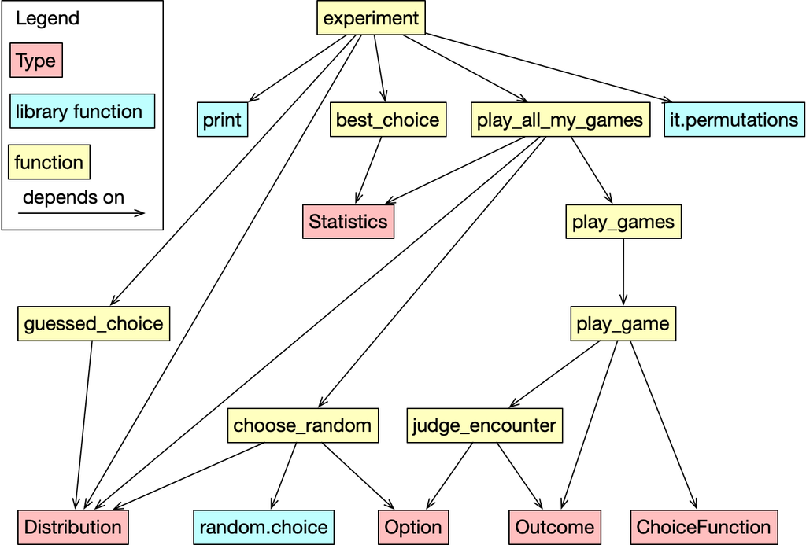

- Compare top-down and bottom-up views
- This is only one design, of many
- Consequences for testing

*Dependence diagrams* for functions (like above) not used often

- But good designers 'see them' in their mind
- Can help
  - understanding
  - pinpoint 'hotspots' (big *fan out*)
  - decide on order of testing (*bottom up*)

`play_all_my_games()` depends on `Distribution` and `choose_random()`

- Can be avoided
- *Generalize* `play_all_my_games()`
- Instead, pass a `ChoiceFunction` for opponent
- One goal of functional decomposition:
  - facilitate reuse
- Let's try

### New RPS Experiment

We want to compare

- a so-called *Markov Chain* Player:
  - never repeats previous choice
  - chooses uniformly between remaining options
  - put differently: probabilities depend on previous choice
- a player who chooses to beat opponent's previous choice
- `ChoiceFunction` is no longer applicable
- Choice depends on something else:
  - own previous choice, or
  - opponent's previous choice
- This could be solved by introducing two extra parameters in `ChoiceFunction`
  - own previous choice
  - opponent's previous choice

  But what if ... it depends on previous *two* choices, etc.?
- It can also be solved by using a *class*
- *Instance variables* keep track of 'past'
- Choice is returned by *method* using instance variables

```python
class MarkovChainChoice:
    """A player who chooses uniformly
    among options different from previous choice.

    First time, chooses uniformly among all options.

    >>> player = MarkovChainChoice()
    >>> choice = player.choose()
    >>> choice in OPTIONS
    True
    >>> player.choose() != choice
    True
    """

    def __init__(self) -> None:
        """Initialize the player.
        """
        self.previous: Optional[Option] = None

    def choose(self) -> Option:
        """Return player's choice.
        """
        options = set(OPTIONS)
        if self.previous is not None:
            options.discard(self.previous)
        choice = random.choice(list(options))
        self.previous = choice
        return choice
```

```python
doctest.run_docstring_examples(MarkovChainChoice, globs=globals(), name='MarkovChainChoice')
```

```python
player = MarkovChainChoice()

[player.choose() for _ in range(20)]
```

```
[1, 2, 1, 0, 2, 0, 1, 2, 1, 2, 0, 2, 1, 0, 2, 1, 2, 0, 1, 2]
```

(How would you beat this player?)

```python
class BeatPreviousChoice:
    """A player who chooses to beat
    opponent's previous choice.

    First time, chooses uniformly among all options.

    Usage:

    1. ``__init__()`` (via constructor)
    2. ``choose()``
    3. ``inform(...)``, repeat from 2

    >>> player = BeatPreviousChoice()
    >>> player.choose() in OPTIONS
    True
    >>> player.inform(ROCK)
    >>> player.choose() == PAPER
    True
    """

    def __init__(self):
        """Initalize the player.
        """
        self.opponent_previous: Optional[Option] = None

    def choose(self) -> Option:
        """Return player's choice.
        """
        if self.opponent_previous is None:
            choice = random.choice(OPTIONS)
        else:
            choice = Option((self.opponent_previous + 1) % len(OPTIONS))
            # could define a separate function for this

        return choice

    def inform(self, opponent_previous: Option) -> None:
        """Inform player of opponent's previous choice.
        """
        self.opponent_previous = opponent_previous
```

```python
doctest.run_docstring_examples(BeatPreviousChoice, globs=globals(), name='BeatPreviousChoice')
```

Function to play $n$ games between these players

```python
def play_games_(n: int,
                player_1: MarkovChainChoice,
                player_2: BeatPreviousChoice
               ) -> Counter[Outcome]:
    """Play n games between MarkovChainChoice player
    and BeatPreviousChoice player,
    returning outcome statistics.
    """
    result: Counter[Outcome] = Counter()

    for _ in range(n):
        choice_1 = player_1.choose()
        choice_2 = player_2.choose()
        outcome = judge_encounter(choice_1, choice_2)
        result[outcome] += 1
        player_2.inform(choice_1)
        # alternative (not recommended): player_2.opponent_previous = choice_1

    return result
```

```python
play_games_(1000, MarkovChainChoice(), BeatPreviousChoice()).most_common()
```

```
[(0, 512), (1, 488)]
```

- Conclusion?
- How can you beat `BeatPreviousChoice` player even more?
- How can you beat `MarkovChainChoice` player?

### Generalization

- Can `play_games` and `play_games_` be *unified*?
  - One function that generalizes both?

What every player needs:

- Ability to choose
- Ability to receive previous choice of opponent
  - can be ignored, if not needed

## OOP: Subclasses and inheritance

*Inheritance* is OO mechanism to create *subclass*

- Subclass *inherits* all methods with definitions from *superclass*
- Subclass can *override* method inherited definitions
- Subclass can *introduce* other instance variables
- Subclass can *introduce* other methods

No copy-paste-edit involved; so, DRY (Don't Repeat Yourself)!

### Abstract RPS player

*Abstract superclass* `Player`

- Not intended for instantiation
- Misses (some) method *definitions*
- Intended to be *subclassed*
- Each *concrete* player class inherits from `Player`
- Each *concrete* player object is also of type `Player`

```python
class Player:
    """An abstract named player for Rock-Paper-Scissors.

    Usage:

    1. ``__init__()`` (via constructor)
    2. ``choose()``
    3. ``inform(...)``, repeat from 2
    """

    def __init__(self, name: str) -> None:
        """Initialize player with given name.
        """
        self.name = name

    def __repr__(self) -> str:
        return f"{self.__class__.__name__}({self.name!r})"

    def __str__(self) -> str:
        return self.name

    def choose(self) -> Option:
        """Choose from OPTIONS for this turn.
        """
        raise NotImplementedError("method is abstract")

    def inform(self, opponent_previous: Option) -> None:
        """Inform player of opponent's previous choice.
        """
        pass  # default behavior: ignore
```

### General function to play RPS game

Define function to play a game between two players

- Definitions of `choose()` and `inform()` are not needed
- Only their type signatures matter

  N.B. Here we decided to play only a single encounter (ties will show up in statistics)

```python
def play_encounter(player_1: Player, player_2: Player) -> Outcome:
    """Play one encounter between two players, returning outcome.
    """
    choice_1, choice_2 = player_1.choose(), player_2.choose()

    player_1.inform(choice_2)
    player_2.inform(choice_1)

    return judge_encounter(choice_1, choice_2)
```

```python
play_encounter(Player("A"), Player("B"))  # fails
```

```
---------------------------------------------------------------------------
NotImplementedError                       Traceback (most recent call last)
/var/folders/dq/bbdqxxcx30zdyfdd26t6vj4c0000gq/T/ipykernel_80041/1957652512.py in <module>
----> 1 play_encounter(Player("A"), Player("B"))  # fails

/var/folders/dq/bbdqxxcx30zdyfdd26t6vj4c0000gq/T/ipykernel_80041/1212511527.py in play_encounter(player_1, player_2)
      2     """Play one encounter between two players, returning outcome.
      3     """
----> 4     choice_1, choice_2 = player_1.choose(), player_2.choose()
      5
      6     player_1.inform(choice_2)

/var/folders/dq/bbdqxxcx30zdyfdd26t6vj4c0000gq/T/ipykernel_80041/188595021.py in choose(self)
     23         """Choose from OPTIONS for this turn.
     24         """
---> 25         raise NotImplementedError("method is abstract")
     26
     27     def inform(self, opponent_previous: Option) -> None:

NotImplementedError: method is abstract
```

```python
def play_games_OO(n: int,
               player_1: Player,
               player_2: Player
              ) -> Counter[Outcome]:
    """Play n encounters between two players,
    returning outcome statistics.
    """
    return Counter(play_encounter(player_1, player_2)
                   for _ in range(n))
```

### How to Define Subclass

Syntax:

```
class SubClass(SuperClass):
    ...
```

### Implement concrete players in subclass

- `ConstPlayer` (me, in first experiment)
- `RandomPlayer` (according to distribution)
- `MarkovPlayer` (accoording to Markov Chain Model)
- `BeatPreviousPlayer` (beat opponent's previous choice)

#### `ConstPlayer`

```python
class ConstPlayer(Player):
    """A constant Player who always chooses the same option.

    >>> player = ConstPlayer("Test", ROCK)
    >>> player
    ConstPlayer('Test', ROCK)
    >>> player.choose()
    0
    """

    def __init__(self, name: str, option: Option) -> None:
        """Initialize player for given option.
        """
        super().__init__(name)
        self.option = option

    def __repr__(self) -> str:
        return (f"{super().__repr__()}"[:-1] +
                f", {option_str[self.option]})"
               )

    # Overrides superclass definition
    def choose(self) -> Option:
        """Choose given option.
        """
        return self.option
```

```python
doctest.run_docstring_examples(ConstPlayer, globs=globals(), name='ConstPlayer')
```

#### `RandomPlayer`

```python
class RandomPlayer(Player):
    """A memoryless random Player, with given distribution.
    """

    def __init__(self, name: str, distr: Distribution) -> None:
        """Initialize player for given distribution.
        """
        super().__init__(name)
        self.distr = distr

    def __repr__(self) -> str:
        return (f"{super().__repr__()}"[:-1] +
                f", {self.distr!r})"
               )

    # Overrides superclass definition
    def choose(self) -> Option:
        """Make random choice according to given distribution.
        """
        return random.choices(OPTIONS, weights=self.distr, k=1)[0]
```

```python
# manual smoke test
distr = [0.1, 0.4, 0.5]
ran_dom = RandomPlayer("Ran Dom", distr)

Counter(ran_dom.choose() for _ in range(1000)).most_common()
```

```
[(2, 508), (1, 392), (0, 100)]
```

```python
me = ConstPlayer("Me", guessed_choice(distr))
print(f"{me!r} vs {ran_dom!r}")
play_games_OO(1000, me, ran_dom).most_common()
```

```
ConstPlayer('Me', ROCK) vs RandomPlayer('Ran Dom', [0.1, 0.4, 0.5])
```

```
[(1, 514), (2, 383), (0, 103)]
```

Let's play all options for me:

```python
stats = {option_str[option]: play_games_OO(1000,
                                           ConstPlayer("Me", option),
                                           ran_dom)
         for option in OPTIONS
        }
stats
```

```
{'ROCK': Counter({2: 375, 1: 523, 0: 102}),
 'PAPER': Counter({1: 100, 0: 392, 2: 508}),
 'SCISSORS': Counter({0: 505, 1: 386, 2: 109})}
```

Now determine ratios of my wins against my losses:

```python
{option: round(counts[Outcome(1)] / counts[Outcome(2)], 2)
 for option, counts in stats.items()
}
```

```
{'ROCK': 1.39, 'PAPER': 0.2, 'SCISSORS': 3.54}
```

So, apparently my best choice is 2 (`SCISSORS`), not 0 (`ROCK`)

```python
# reverse sort on win/loss ratio (best at top)
sorted(((option_str[option], play_games_OO(1000,
                                           ConstPlayer("Me", option),
                                           ran_dom)
       )
        for option in OPTIONS
      ),
       key=lambda t: t[1][Outcome(1)] / t[1][Outcome(2)],
       reverse=True
      )
```

```
[('SCISSORS', Counter({0: 474, 1: 417, 2: 109})),
 ('ROCK', Counter({2: 394, 1: 504, 0: 102})),
 ('PAPER', Counter({1: 87, 2: 497, 0: 416}))]
```

#### `MarkovPlayer`

Given: a distribution for each previous choice (by this player)

- That is, for each previous choice, there is a separate probability distribution for next choice
- A.k.a. *Markov Model of order 1*

```python
MarkovModel_1 = Mapping[Option, Distribution]
```

```python
class MarkovPlayer(Player):
    """A player who chooses according
    to given order-1 Markov model.

    First time, chooses uniformly among all options.
    """

    def __init__(self, name: str, mm: MarkovModel_1) -> None:
        """Initialize the player for given Markov model.
        """
        super().__init__(name)
        self.mm = mm
        self.previous: Optional[Option] = None

    def choose(self) -> Option:
        """Return player's choice.
        """
        distr: Distribution  # (needed for type checking)
        if self.previous is None:
            distr = [1, 1, 1]
        else:
            distr = self.mm[self.previous]
        choice = random.choices(OPTIONS, weights=distr, k=1)[0]
        self.previous = choice
        return choice
```

```python
mm = {ROCK:     [0.0, 0.5, 0.5],
      PAPER:    [0.5, 0.0, 0.5],
      SCISSORS: [0.5, 0.5, 0.0],
     }
markov = MarkovPlayer("Mark Ov", mm)

[markov.choose() for _ in range(20)]
```

```
[2, 1, 0, 2, 1, 0, 1, 0, 1, 0, 1, 2, 0, 1, 2, 1, 2, 0, 1, 2]
```

```python
# Overall statistics

Counter(markov.choose() for _ in range(10000))
```

```
Counter({0: 3333, 2: 3342, 1: 3325})
```

### Intermezzo: Uniform versus Independent

Two ways in which RPS choices can be 'bad':

- Not *uniformly* distributed
- Not *independently* distributed
- `RandomPlayer("Ran Dom", [0.1, 0.4, 0.5])`
  - *not* uniform
  - but all choices are independent (no memory effect)
- `MarkovPlayer("Mark Ov", mm)`
  - *not* independent (memory effect)
  - but choices are uniform (overall)

Both can be exploited

#### `BeatPreviousPlayer`

```python
class BeatPreviousPlayer(Player):
    """A player who chooses to beat
    opponent's previous choice.

    First time, chooses uniformly among all options.

    >>> player = BeatPreviousPlayer("Test")
    >>> player.choose() in OPTIONS
    True
    >>> player.inform(ROCK)
    >>> player.choose() == PAPER
    True
    """

    def __init__(self, name: str):
        """Initalize the player.
        """
        super().__init__(name)
        self.opponent_previous: Optional[Option] = None

    def choose(self) -> Option:
        if self.opponent_previous is None:
            choice = random.choice(OPTIONS)
        else:
            choice = Option((self.opponent_previous + 1) % len(OPTIONS))

        return choice

    def inform(self, opponent_previous: Option) -> None:
        self.opponent_previous = opponent_previous
```

```python
doctest.run_docstring_examples(BeatPreviousPlayer, globs=globals(), name='BeatPreviousPlayer')
```

```python
beat_previous = BeatPreviousPlayer("Beat Prev")

print(f"{markov!r} vs {beat_previous!r}")
play_games_OO(1000, markov, beat_previous)
```

```
MarkovPlayer('Mark Ov') vs BeatPreviousPlayer('Beat Prev')
```

```
Counter({1: 498, 0: 502})
```

#### Notes about players

- `ConstPlayer` and `RandomPlayer` are *immutable*
- `MarkovPlayer` and `BeatPreviousPlayer` are *mutable*
- Many other strategies imaginable
- Track statistics of opponent's choices and create a Markov model to predict its behavior.

How would you play?

Can you imagine a way of playing an RPS *tournament*?

- All kinds of players play against each other

### Polymorphism

Observe that `play_game_OO` needed no changes when introducing new types of players.

The parameters `player_1` and `player_2` of type `Player` accepted objects of *subclasses* of `Player` as well.

Parameters `player_1` and `player_2` are **polymorphic**.

**Polymorphism** ("taking on multiple forms"):

- the actual *run-time type* can be a *subclass* of the *declared type*

```python
issubclass(ConstPlayer, Player)
```

```
True
```

```python
issubclass(ConstPlayer, RandomPlayer)
```

```
False
```

```python
type(me), isinstance(me, ConstPlayer), isinstance(me, Player)
```

```
(__main__.ConstPlayer, True, True)
```

### Notes about inheritance

- Use sparingly (prefer *composition*).
  - Only in case of 'is-a' relationship
  - A `RandomPlayer` is a (kind of) `Player`
- Inheritance can help avoid *code duplication* (DRY).

  Attributes and methods are inherited from *superclass* without copying code.
- Inheritance can be used to *add* attributes/methods.
- Inheritance can be used to *change* (**override**) method behavior.

  Use `super()` to invoke behavior of superclass.

## More RPS Classes (via composition)

We can do further data decomposition

- `OutcomeStats`
  - holds count per outcome (composition)
  - can print nicely
  - can compute win fraction
- `Referee`
  - holds two players (composition)
  - can play one or more encounters

### `OutcomeStats`

```python
WIN = Outcome(1)
LOSS = Outcome(2)

class OutcomeStats:
    """A count per outcome (mutable).

    >>> stats = OutcomeStats()
    >>> stats
    OutcomeStats(Counter())
    >>> print(stats)
    0 wins - 0 ties - 0 losses
    >>> stats.win_fraction()
    Traceback (most recent call last):
        ...
    AssertionError: No wins and losses
    >>> stats.update([WIN])
    >>> stats.win_fraction()
    1.0
    >>> stats.update([LOSS, TIE, LOSS, TIE, LOSS])
    >>> stats.win_fraction()
    0.25
    >>> print(stats)
    1 wins - 2 ties - 3 losses
    """

    def __init__(self, counts: Counter[Outcome] = None) -> None:
        self.counts: Counter[Outcome]  # (needed for type checking)
        if counts is None:
            self.counts = Counter()
        else:
            self.counts = counts

    def __repr__(self) -> str:
        return f"{self.__class__.__name__}({self.counts!r})"

    def __str__(self) -> str:
        return ' - '.join([f"{self.counts[WIN]} wins",
                           f"{self.counts[TIE]} ties",
                           f"{self.counts[LOSS]} losses",
                          ])

    def update(self, iterable: Iterable[Outcome]) -> None:
        """Update with all given outcomes.
        """
        self.counts.update(iterable)

    def win_fraction(self) -> float:
        """Return fraction win / (win + loss).
        """
        win_loss = self.counts[WIN] + self.counts[LOSS]
        assert  win_loss != 0, 'No wins and losses'
        return self.counts[WIN] / win_loss
```

```python
doctest.run_docstring_examples(OutcomeStats, globs=globals(), name='OutcomStats')
```

### `Referee`

```python
class Referee:
    """A referee for RPS games between two given players
    (immutable).
    """

    def __init__(self, player_1: Player, player_2: Player) -> None:
        """Initialize referee with two given players.
        """
        self.player_1 = player_1
        self.player_2 = player_2

    def play_encounter(self) -> Outcome:
        """Play one encounter between the two players,
        returning outcome.
        """
        choice_1 = self.player_1.choose()
        choice_2 = self.player_2.choose()

        self.player_1.inform(choice_2)
        self.player_2.inform(choice_1)

        return judge_encounter(choice_1, choice_2)

    def play_games(self, n: int, verbose=False) -> OutcomeStats:
        """Play n encounters between the two players,
        returning outcome statistics.
        """
        stats = OutcomeStats()
        stats.update(self.play_encounter()
                     for _ in range(n))
        if verbose:
            print(f"{self.player_1!r} vs {self.player_2!r}")
            print(stats)
            print(f"win fraction: {stats.win_fraction():1.2f}")

        return stats
```

```python
referee = Referee(markov, beat_previous)

referee.play_games(1000, True)
```

```
MarkovPlayer('Mark Ov') vs BeatPreviousPlayer('Beat Prev')
477 wins - 523 ties - 0 losses
win fraction: 1.00
```

```
OutcomeStats(Counter({0: 523, 1: 477}))
```

```python
for option in OPTIONS:
    referee = Referee(ConstPlayer("Me", option),
                      RandomPlayer("Ran Dom", [0.1, 0.4, 0.5])
                     )
    referee.play_games(1000, True)
    print()
```

```
ConstPlayer('Me', ROCK) vs RandomPlayer('Ran Dom', [0.1, 0.4, 0.5])
501 wins - 92 ties - 407 losses
win fraction: 0.55

ConstPlayer('Me', PAPER) vs RandomPlayer('Ran Dom', [0.1, 0.4, 0.5])
101 wins - 393 ties - 506 losses
win fraction: 0.17

ConstPlayer('Me', SCISSORS) vs RandomPlayer('Ran Dom', [0.1, 0.4, 0.5])
387 wins - 508 ties - 105 losses
win fraction: 0.79
```

## Data Decompsition for RPS Experiments

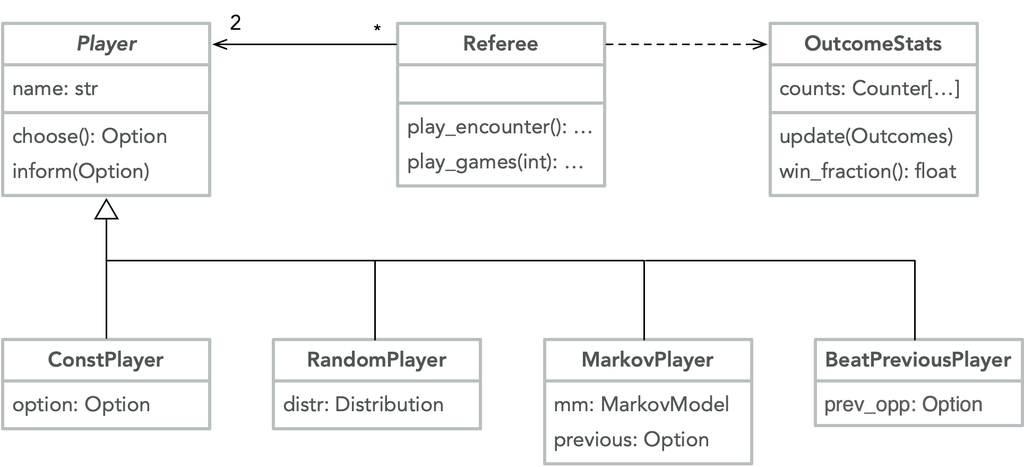

*Dependence diagrams* for classes (like above) often used

- Diagram notation: *Unified Modeling Language* (UML)
- Note how all experiments were supported
- Recommendation: *encapsulate* `Distribution` and `MarkovModel` in a class

Also see: [Inheritance and Composition: A Python OOP Guide](https://realpython.com/inheritance-composition-python/)

## Argument Gathering

Goals:

- Call a function having multiple parameters, such that  
  *each argument is taken from a sequence or dictionary*.
- Define a function with a *variable number of arguments*.

### Argument unpacking for positional arguments

Example: [Multiply-accumulate operation](https://en.wikipedia.org/wiki/Multiply%E2%80%93accumulate_operation)

- `a += b * c`

```python
def mac(a: float, b: float, c: float) -> float:
    """Multiply accumulate operation.

    >>> mac(0, 1, 2)
    2
    >>> mac(1, 2, 3)
    7
    """
    return a + b * c
```

```python
doctest.run_docstring_examples(mac, globals(), True, 'mac')
```

```
Finding tests in mac
Trying:
    mac(0, 1, 2)
Expecting:
    2
ok
Trying:
    mac(1, 2, 3)
Expecting:
    7
ok
```

```python
args = [2, 3, 4]

# we want to do mac(args[0], args[1], args[2])
mac(*args)  # NOTE the *
```

```
14
```

```python
args = (mac, globals(), True, 'mac')

doctest.run_docstring_examples(*args)  # NOTE the *
```

```
Finding tests in mac
Trying:
    mac(0, 1, 2)
Expecting:
    2
ok
Trying:
    mac(1, 2, 3)
Expecting:
    7
ok
```

### Argument unpacking for keyword arguments

```python
kwargs: Mapping[str, Any] = {
    'f': mac,
    'globs': globals(),
    'verbose': True,
    'name': 'mac'
}

doctest.run_docstring_examples(**kwargs)  # NOTE the **
```

```
Finding tests in mac
Trying:
    mac(0, 1, 2)
Expecting:
    2
ok
Trying:
    mac(1, 2, 3)
Expecting:
    7
ok
```

Can also be mixed.

Positional arguments always precede keyword arguments:

```python
args = (mac, globals())
kwargs = {'verbose': True, 'name': 'mac'}

doctest.run_docstring_examples(*args, **kwargs)  # NOTE the * and **
```

```
Finding tests in mac
Trying:
    mac(0, 1, 2)
Expecting:
    2
ok
Trying:
    mac(1, 2, 3)
Expecting:
    7
ok
```

### Functions with variable number of arguments

```python
def print_args(*args: Any, **kwargs: Any) -> None:
    """Print each positional and keyword argument.

    >>> print_args('a', 'b')
    position 0 = 'a'
    position 1 = 'b'
    >>> print_args(42, a=1)
    position 0 = 42
    a = 1
    >>> print_args(first=1, second=2)
    first = 1
    second = 2
    """
    for index, arg in enumerate(args):
        print(f"position {index} = {arg!r}")
    for kw, val in kwargs.items():
        print(f"{kw} = {val!r}")
```

```python
args = (print_args, globals())
kwargs = {'verbose': True, 'name': 'print_args'}

doctest.run_docstring_examples(*args, **kwargs)
```

```
Finding tests in print_args
Trying:
    print_args('a', 'b')
Expecting:
    position 0 = 'a'
    position 1 = 'b'
ok
Trying:
    print_args(42, a=1)
Expecting:
    position 0 = 42
    a = 1
ok
Trying:
    print_args(first=1, second=2)
Expecting:
    first = 1
    second = 2
ok
```

[figure not shown]

## Recursion

**Recursive** function: defined (directly or indirectly) in terms of itself

Image source: https://en.wikipedia.org/wiki/Droste_effect

```python
def print_triangle_recursive(n: int) -> None:
    """Print an o-triangle with base n.

    Assumption: n >= 0

    >>> print_triangle_recursive(3)
    ooo
    oo
    o
    """
    if n == 0:
        pass  # done
    else:
        print(n * "o")
        print_triangle_recursive(n - 1)
```

```python
print_triangle_recursive(5)
```

```
ooooo
oooo
ooo
oo
o
```

### Leap of faith

To understand this definition:

- Don't try to play out the possible executions of all the recursive calls.
- Rather, make a **leap of faith** (cf. *Think Python*, Section 6.6):
  - Understand that the function works correctly, *under the assumption* that  
    the function already works for 'smaller' values of the parameters
- Compare this to a **proof by induction**:
  - the assumption serves as **induction hypothesis**

### Notes

- Recursive definitions are like `while` loops:
  - They can lead to *infinite* computations;
  - You have to ensure **termination**

### Recursion for variable number of nested loops

All 4-bit binary numbers can be generated using 4 nested loops:

```python
BIT = range(2)

def binary_numbers_4() -> Iterator[Tuple[int, int, int, int]]:
    """Yield all 4-bit tuples, in lexicographic order.
    """
    for b1 in BIT:
        for b2 in BIT:
            for b3 in BIT:
                for b4 in BIT:
                    yield b1, b2, b3, b4
```

```python
for t in binary_numbers_4():
    print(t)
```

```
(0, 0, 0, 0)
(0, 0, 0, 1)
(0, 0, 1, 0)
(0, 0, 1, 1)
(0, 1, 0, 0)
(0, 1, 0, 1)
(0, 1, 1, 0)
(0, 1, 1, 1)
(1, 0, 0, 0)
(1, 0, 0, 1)
(1, 0, 1, 0)
(1, 0, 1, 1)
(1, 1, 0, 0)
(1, 1, 0, 1)
(1, 1, 1, 0)
(1, 1, 1, 1)
```

```python
print(*binary_numbers_4(), sep='\n')
```

```
(0, 0, 0, 0)
(0, 0, 0, 1)
(0, 0, 1, 0)
(0, 0, 1, 1)
(0, 1, 0, 0)
(0, 1, 0, 1)
(0, 1, 1, 0)
(0, 1, 1, 1)
(1, 0, 0, 0)
(1, 0, 0, 1)
(1, 0, 1, 0)
(1, 0, 1, 1)
(1, 1, 0, 0)
(1, 1, 0, 1)
(1, 1, 1, 0)
(1, 1, 1, 1)
```

### Generate all $n$-bit binary tuples

We want to define the following function:

```python
def binary_numbers(n: int) -> Iterator[Tuple[int, ...]]:
    """Yield all n-bit binary tuples in lexicographic order.

    Assumptions:

    * n >= 0

    >>> list(binary_numbers(0))
    [()]
    >>> binary_numbers(2)
    [(0, 0), (0, 1), (1, 0), (1, 1)]
    """
```

In a way, we need a *variable number* of nested `for`-loops

Can be achieved via:

- Recursion

Note the *recursive pattern* in the desired output

```python
for index, t in enumerate(binary_numbers_4()):
    print("{}  {}{}{}".format(*t),
          end='\n\n' if index == 7 else '\n')
```

```
0  000
0  001
0  010
0  011
0  100
0  101
0  110
0  111

1  000
1  001
1  010
1  011
1  100
1  101
1  110
1  111
```

```python
def binary_numbers(n: int) -> Iterator[Tuple[int, ...]]:
    """Yield all n-bit binary tuples in lexicographic order.

    Assumptions:

    * n >= 0

    >>> list(binary_numbers(0))
    [()]
    >>> list(binary_numbers(2))
    [(0, 0), (0, 1), (1, 0), (1, 1)]
    """
    if n == 0:
        # base case
        yield ()
    else:
        # inductive step
        for b in BIT:
            for t in binary_numbers(n - 1):
                yield (b, ) + t
```

```python
doctest.run_docstring_examples(binary_numbers, globs=globals(), name='binary_numbers')
```

```python
for u in binary_numbers(4):
    print(*u)
```

```
0 0 0 0
0 0 0 1
0 0 1 0
0 0 1 1
0 1 0 0
0 1 0 1
0 1 1 0
0 1 1 1
1 0 0 0
1 0 0 1
1 0 1 0
1 0 1 1
1 1 0 0
1 1 0 1
1 1 1 0
1 1 1 1
```

### Branching recursion

- Each call, except base case,
  - results in *two* recursive calls
- *Exponential growth*
- Jargon: *backtracking*, *exhaustive search*

```python
def binary_numbers_(n: int, indent='') -> Iterator[Tuple[int, ...]]:
    """Yield all n-bit binary tuples in lexicographic order.

    Assumptions: n >= 0
    """
    print(indent, f"binary_numbers_({n})", sep='')
    if n == 0:
        # base case
        yield ()
    else:
        # inductive step
        for b in BIT:
            for t in binary_numbers_(n - 1, indent + 4 * ' '):
                yield (b, ) + t
```

```python
for u in binary_numbers_(4):
    pass
```

```
binary_numbers_(4)
    binary_numbers_(3)
        binary_numbers_(2)
            binary_numbers_(1)
                binary_numbers_(0)
                binary_numbers_(0)
            binary_numbers_(1)
                binary_numbers_(0)
                binary_numbers_(0)
        binary_numbers_(2)
            binary_numbers_(1)
                binary_numbers_(0)
                binary_numbers_(0)
            binary_numbers_(1)
                binary_numbers_(0)
                binary_numbers_(0)
    binary_numbers_(3)
        binary_numbers_(2)
            binary_numbers_(1)
                binary_numbers_(0)
                binary_numbers_(0)
            binary_numbers_(1)
                binary_numbers_(0)
                binary_numbers_(0)
        binary_numbers_(2)
            binary_numbers_(1)
                binary_numbers_(0)
                binary_numbers_(0)
            binary_numbers_(1)
                binary_numbers_(0)
                binary_numbers_(0)
```

### Another *recursive pattern*

```python
for index, t in enumerate(binary_numbers_4()):
    print("{}{}{}  {}".format(*t),
          end='\n\n' if index % 2 == 1 else '\n')
```

```
000  0
000  1

001  0
001  1

010  0
010  1

011  0
011  1

100  0
100  1

101  0
101  1

110  0
110  1

111  0
111  1
```

```python
def binary_numbers_2(n: int) -> Iterator[Tuple[int, ...]]:
    """Yield all n-bit binary tuples in lexicographic order.

    Assumptions:

    * n >= 0

    >>> list(binary_numbers_2(0))
    [()]
    >>> list(binary_numbers_2(2))
    [(0, 0), (0, 1), (1, 0), (1, 1)]
    """
    if n == 0:
        # base case
        yield ()
    else:
        # inductive step
        for t in binary_numbers_2(n - 1):
            for b in BIT:
                yield t + (b, )
```

```python
doctest.run_docstring_examples(binary_numbers_2, globs=globals(), name='binary_numbers_2')
```

```python
for u in binary_numbers_2(4):
    print(*u)
```

```
0 0 0 0
0 0 0 1
0 0 1 0
0 0 1 1
0 1 0 0
0 1 0 1
0 1 1 0
0 1 1 1
1 0 0 0
1 0 0 1
1 0 1 0
1 0 1 1
1 1 0 0
1 1 0 1
1 1 1 0
1 1 1 1
```

### Generalized problem

Observe another pattern:

```python
for index, t in enumerate(binary_numbers_4()):
    print("{}{}  {}{}".format(*t),
          end='\n\n' if index % 4 == 3 else '\n')
```

```
00  00
00  01
00  10
00  11

01  00
01  01
01  10
01  11

10  00
10  01
10  10
10  11

11  00
11  01
11  10
11  11
```

- Function `binary_numbers_gen(n, t)`
  - generates all binary tuples in increasing order
  - that *extend* given tuple `t` with `n` bits,
- Assumption: `n >= 0`

Function `binary_numbers_gen` *generalizes* `binary_numbers`:

- To get original problem, take `t == ()`
- `binary_numbers_gen(n, ())` yields the same as `binary_numbers(n)`
- `binary_numbers` is *special case* of `binary_numbers_gen`

Solution:

- Do induction on `n`
- Base case: `n == 0`, then only `t` generated
- Inductive step: `n > 0`
  - Induction hypothesis: recursive call with smaller `n` 'works' as expected
  - Extend `t` in all possible ways with *one* bit `b`: `t + (b, )`
  - Call function with `n - 1` and `t + (b, )`

```python
def binary_numbers_gen(n: int, t: Tuple[int, ...] = ()) -> Iterator[Tuple[int, ...]]:
    """Yield all binary numbers that extend t with n bits,
    in increasing order.

    Assumptions:

    * n >= 0

    >>> list(binary_numbers_gen(0))
    [()]
    >>> list(binary_numbers_gen(2, (0, 1)))
    [(0, 1, 0, 0), (0, 1, 0, 1), (0, 1, 1, 0), (0, 1, 1, 1)]
    """
    if n == 0:
        # base case
        yield t
    else:
        # inductive step
        for b in BIT:
            yield from binary_numbers_gen(n - 1, t + (b, ))
```

```python
doctest.run_docstring_examples(binary_numbers_gen, globals(), verbose=False, name='binary_numbers_gen')
```

Syntax:

```
yield from iterable
```

Semantics:

```
for item in iterable
    yield item
```

```python
for u in binary_numbers_gen(4):
    print(*u)
```

```
0 0 0 0
0 0 0 1
0 0 1 0
0 0 1 1
0 1 0 0
0 1 0 1
0 1 1 0
0 1 1 1
1 0 0 0
1 0 0 1
1 0 1 0
1 0 1 1
1 1 0 0
1 1 0 1
1 1 1 0
1 1 1 1
```

### Solution from Python Standard Library

```python
for u in it.product(BIT, repeat=4):
    print(*u)
```

```
0 0 0 0
0 0 0 1
0 0 1 0
0 0 1 1
0 1 0 0
0 1 0 1
0 1 1 0
0 1 1 1
1 0 0 0
1 0 0 1
1 0 1 0
1 0 1 1
1 1 0 0
1 1 0 1
1 1 1 0
1 1 1 1
```

## (End of Notebook)

© 2019-2023 - **TU/e** - Eindhoven University of Technology - Tom Verhoeff